# Three ways to Understand the Mixed Product of Vectors! 向量混合积的三种理解

Differential-Geometry

When it comes to $a \cdot (b \times c)$, what’s in your head?

Author

Marcobisky

Published

March 9, 2025

## 1 Hello!

This property of vector operation bother me for a loooooong time:

**Mixed product**[^1]:
$$\boxed{
a \cdot (b \times c) = b \cdot (c \times a) = c \cdot (a \times b).
}
\tag{1}$$

<sup>1</sup> Also known as “scalar triple product”.

This says nothing but the mixed product is unchanged under a circular shift.

You will understand it in this article!

## 2 Three Approaches to the Mixed Product

**Lemma**

**Lemma 1** Let $a, b, c \in \mathbb{R}^3$, then
$$a \cdot (b \times c) =
\begin{vmatrix}
| & | & | \\
a & b & c \\
| & | & |
\end{vmatrix}$$

Once this is established, we can use the fact that:
$$\begin{vmatrix}
| & | & | \\
a & b & c \\
| & | & |
\end{vmatrix} =
\begin{vmatrix}
| & | & | \\
b & c & a \\
| & | & |
\end{vmatrix} =
\begin{vmatrix}
| & | & | \\
c & a & b \\
| & | & |
\end{vmatrix}$$
to prove Equation 1.

Now let’s understand Lemma 1 in three different ways!

### 2.1 Geometric Approach

See Figure 1, dot product make the slanted black box straight but maintains its volume.

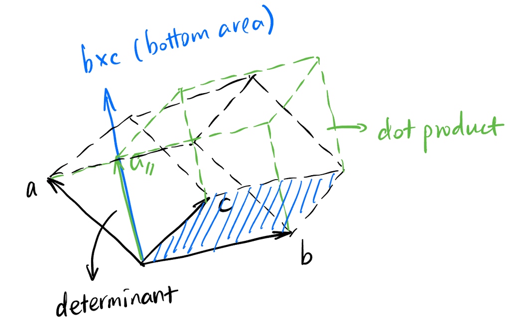

Figure 1: Geometric proof of Lemma 1

### 2.2 3b1b Approach

I called this “3b1b Approach” because this method is inspired by a great mathematician Grant Sanderson. “3b1b” is the name of [his Youtube channel](https://www.youtube.com/@3blue1brown).

In a [video](https://www.youtube.com/watch?v=BaM7OCEm3G0) created by him, there is a very interesting function $f: \mathbb{R}^3 \to \mathbb{R}$:
$$f(x) =
\begin{vmatrix}
| & | & | \\
x & v & w \\
| & | & |
\end{vmatrix}
\tag{2}$$
which takes in a vector in $\mathbb{R}^3$ and output a number in $\mathbb{R}$ ($v$ and $w$ are predefined and fixed).[^2] Now I claim that:

<sup>2</sup> Functions from a vector space to a scalar is often referred to as a *functional*.

**Claim**

**Theorem 1** The functional $f$ in Equation 2 is *linear*, i.e.,
$$f(x + y) = f(x) + f(y), \forall x, y \in \mathbb{R}^3$$
and
$$f(\alpha x) = \alpha f(x), \forall \alpha \in \mathbb{R}.$$

This is trivial.

There is another theorem[^3]:

<sup>3</sup> There is a [video](https://www.bilibili.com/video/BV1AterevErt/?spm_id_from=333.1387.list.card_archive.click&vd_source=42579e22289b6144ba0b2bdcf99834e3) created by myself that explains this in detail.

**Riesz Representation Theorem (reduced version)**

**Theorem 2** Every linear functional in $\mathbb{R}^n$ induces a vector $p \in \mathbb{R}^n$ such that
$$f(x) = x \cdot p, \forall x \in \mathbb{R}^n.$$

Therefore, Equation 2 becomes
$$\boxed{
x \cdot p =
\begin{vmatrix}
| & | & | \\
x & v & w \\
| & | & |
\end{vmatrix}
}
\tag{3}$$

**Mnemonic device inspired by Equation 3**

The Equation 3 gives us a way to write the cross product in a more “dot-product” way:
$$v \times w =
\begin{vmatrix}
\hat{\imath} & v_1 & w_1 \\
\hat{\jmath} & v_2 & w_2 \\
\hat{k} & v_3 & w_3
\end{vmatrix}$$
because the result $v \times w = (v_2w_3 - v_3w_2)\hat{\imath} + (v_3w_1 - v_1w_3)\hat{\jmath} + (v_1w_2 - v_2w_1)\hat{k}$ is very much like a dot product! Remember $v_2w_3 - v_3w_2, v_3w_1 - v_1w_3, v_1w_2 - v_2w_1$ are just three numbers unless you you associate each number with a direction.

If you feel uncomfortable with this notation, there is more:
$$\operatorname{curl} F
\equiv \nabla \times F =
\begin{vmatrix}
\hat{\imath} & \frac{\partial}{\partial x} & F_x \\
\hat{\jmath} & \frac{\partial}{\partial y} & F_y \\
\hat{k} & \frac{\partial}{\partial z} & F_z
\end{vmatrix}$$
where we treat $\nabla$ like a vector! The first column is just an indicator that the result should be interpreted as a vector not a dot product. I took long time to think $\nabla$ as a kind of special vector, but I failed. Feel free to ignore the notation $\nabla \times F$ if you don’t like it!

What is $p$ then? Well, **$p$ is a special vector in $\mathbb{R}^3$ such that the dot product with *any* vector $x$ gives a number that is equal to the volume of a box spaned by $x$, $v$, and $w$.** This is a little bit mouthful, but we can see immediately from Figure 1 that $p$ is just the blue vector, which is $v \times w$ in this case! So Equation 3 becomes:
$$x \cdot (v \times w) = \begin{vmatrix}
| & | & | \\
x & v & w \\
| & | & |
\end{vmatrix}$$

We are done!

### 2.3 Tensor Approach

Now this explanation requires some knowledge about tensors[^4]. But once you understand it, **you will completely change your view on *determinants***! (If you did not respect them at all in the past anyway.)

<sup>4</sup> Just a quick joke, tensors are exactly linear functionals but we allow multiple vectors to be the input (instead of one).

**Proposition**

**Proposition 1** The mapping $g(a, b, c) := a \cdot (b \times c)$ and $\det$ are both alternating 3-tensor, i.e.,
$$g, \det \in \bigwedge\nolimits^{\!3} \left(\mathbb{R}^3\right).
\tag{4}$$

We also have this theorem:

**Uniqueness of volume form**

**Theorem 3** The dimension of the vector space of $k$-tensors on $\mathbb{R}^n$ is ${n \choose k}$:
$$\operatorname{dim} \bigwedge\nolimits^{\!k} \left(\mathbb{R}^n\right) = {n \choose k}.$$

**Demonstration of Theorem 3**

Pick $n = 3$ and $k = 2$. This is because in order to get the result of a $2$-tensor[^5] $B$ acting on *any* two vectors of dimension $3$, we would only need to specify the values of $B$ acting on any $2$ of the three basis vectors ($e_x, e_y, e_z$). How many numbers do we need? Well, only ${3 \choose 2} = 3$ numbers:
$$B(e_x, e_y) = a_{12}, B(e_y, e_z) = a_{23}, B(e_z, e_x) = a_{31}.$$

These are the “basis” of the space $\bigwedge\nolimits^{\!2} \left(\mathbb{R}^3\right)$. So its dimension is $3$. Then we just use the bilinear and alternating property of $B$ to calculate the result of *any* two input vectors say $x = 2e_x + e_y - e_z$ and $y = -e_x + 3e_z$:
$$\begin{aligned}
B(x, y)
&= B(2e_x + e_y - e_z, -e_x + 3e_z) \\
&= B(2e_x + e_y - e_z, -e_x) + B(2e_x + e_y - e_z, 3e_z) \\
&= -2B(e_x, e_x) - B(e_y, e_x) + B(e_z, e_x) \\
&+ 6B(e_x, e_z) + 3B(e_y, e_z) - 3B(e_z, e_z) \\
&= 0 - (-a_{12}) + a_{31} \\
&+ 6(-a_{31}) + 3a_{23} - 0 \\
&= a_{12} + 3a_{23} - 5a_{31}.
\end{aligned}$$

<sup>5</sup> This is also called an alternating bilinear form.

<sup>6</sup> This type of tensor is also called “volume form”.

As a special case[^6] when $n = k = 3$, we have:
$$\boxed{
\operatorname{dim} \bigwedge\nolimits^{\!3} \left(\mathbb{R}^3\right) = {3 \choose 3} = 1.
}$$

Let’s think about what this means. **The determinant is a very special object that *every* volume form in $n$ dimension is just a scalar multiple of it! In other words, *every* alternating $n$-tensor in $\mathbb{R}^n$ must be the determinant (up to a scalar)!** So with Equation 4, both $g$ and $\det$ are volume forms! So $g$ must be a scalar multiple of $\det$:
$$g = k \det.$$

We can evaluate $k$ by choosing a very special set of $a, b, c \in \mathbb{R}^3$, say $a = e_x, b = e_y, c = e_z$:
$$g(e_x, e_y, e_z) = e_x \cdot (e_y \times e_z) = e_x \cdot e_x = 1,$$
$$\det(e_x, e_y, e_z) =
\begin{vmatrix}
1 & 0 & 0 \\
0 & 1 & 0 \\
0 & 0 & 1
\end{vmatrix} = 1.$$

Therefore, $k = 1$ and $g = \det$. We are done!